# Day 3: Discrete Distribution Models

## Picking the distribution

**Observation model:**

$$y_i \sim \text{NB}( \mu_i, \theta )$$
**Process model:**

The process model will have the log link and the predictors

Informal formula style:

$$log(\mu_i) = year * works + (1|reach)$$

Technical formula style:
$$\begin{align}
log(\mu_i) &= \alpha + \beta_1 year + \beta_2 works + \beta_3 (year*works) + \epsilon_{reach_i} \\
\epsilon_{reach_i} & \sim \text{N}(0, \sigma_{reach_i}^2)
\end{align}$$

## Run the Model

### brms model

```r
  library(brms)
  mod_mc <- brm( catch ~ year*works + (1|reach_id) , data=ds_mc, family=negbinomial()  )
     saveRDS(mod_mc,'data/mod_mc.rds')
```

### check convergence

Check the Rhats (<1.01) in model output

```r
  mod_mc
```

```
 Family: negbinomial
  Links: mu = log; shape = identity
Formula: catch ~ year * works + (1 | reach_id)
   Data: ds_mc (Number of observations: 105)
  Draws: 4 chains, each with iter = 2000; warmup = 1000; thin = 1;
         total post-warmup draws = 4000

Multilevel Hyperparameters:
~reach_id (Number of levels: 15)
              Estimate Est.Error l-95% CI u-95% CI Rhat Bulk_ESS
sd(Intercept)     0.19      0.15     0.01     0.54 1.00     1619
              Tail_ESS
sd(Intercept)     1638

Regression Coefficients:
                Estimate Est.Error l-95% CI u-95% CI Rhat Bulk_ESS
Intercept           1.36      0.36     0.68     2.09 1.00     1764
year                0.07      0.09    -0.12     0.25 1.00     1789
worksBasic          0.18      0.51    -0.83     1.19 1.00     1790
worksIWH            0.45      0.52    -0.59     1.46 1.00     1937
year:worksBasic    -0.02      0.13    -0.28     0.24 1.00     1748
year:worksIWH       0.08      0.14    -0.20     0.35 1.00     1895
                Tail_ESS
Intercept           2355
year                2287
worksBasic          2135
worksIWH            2640
year:worksBasic     2347
year:worksIWH       2269

Further Distributional Parameters:
      Estimate Est.Error l-95% CI u-95% CI Rhat Bulk_ESS Tail_ESS
shape     1.01      0.17     0.73     1.38 1.00     4203     3485

Draws were sampled using sampling(NUTS). For each parameter, Bulk_ESS
and Tail_ESS are effective sample size measures, and Rhat is the potential
scale reduction factor on split chains (at convergence, Rhat = 1).
```

**Tip: Check the shape parameter estimate (shape = $\theta$ = “clumped”). If $\theta$>10, then worth re-running as Poisson**

Check the trace plots

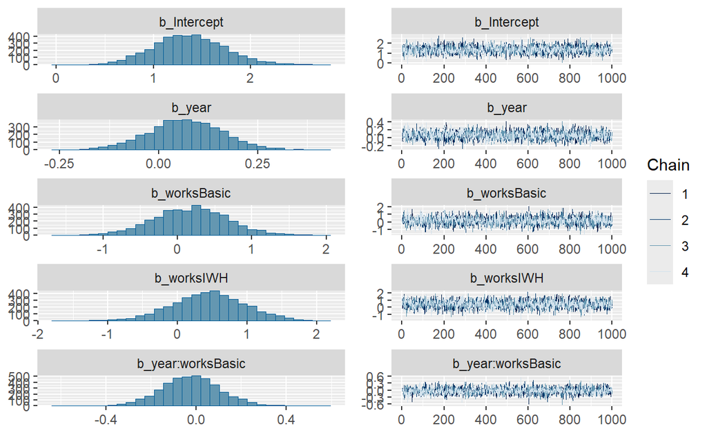

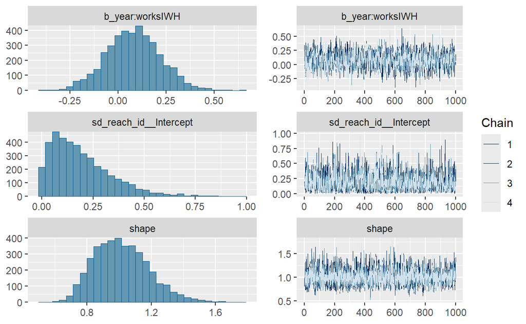

```r
  plot(mod_mc)
```

### check model assumptions

Lets do DHARMa quantile approach and pp_check from Day2

**DHARMa**

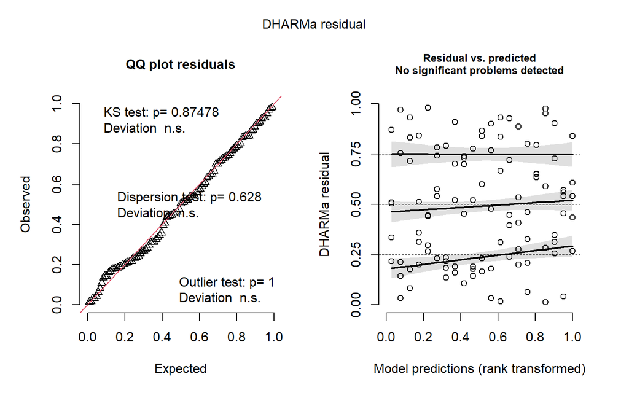

```r
  check_brms(mod_mc)
```

**PP check**

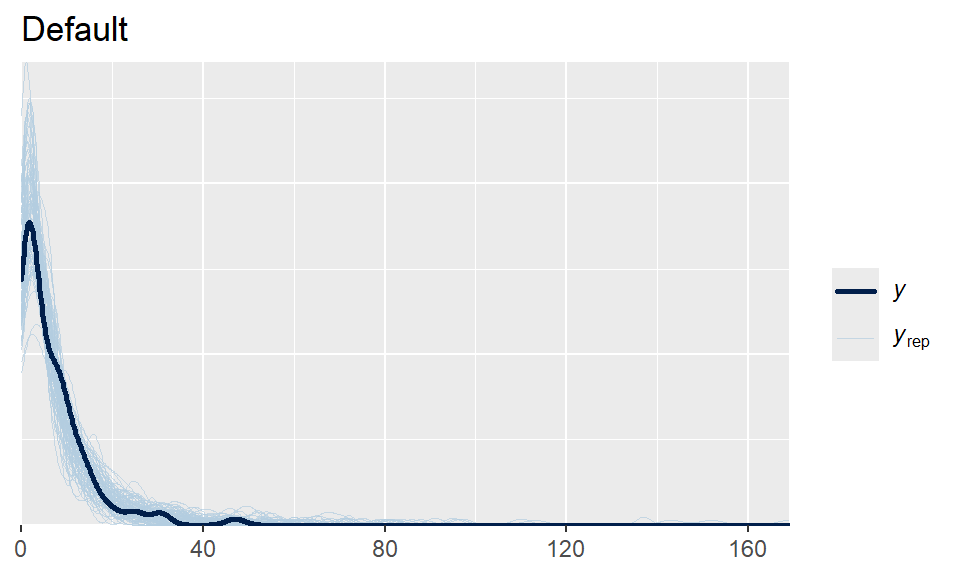

```r
  pp_check(mod_mc, ndraw=100) + labs(title='Default')
```

**Residuals vs fitted**

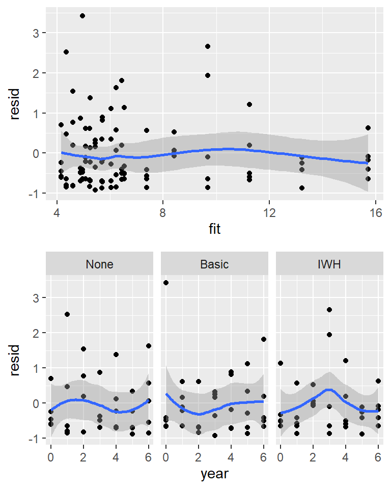

```r
  ds_mc$fit <- fitted(mod_mc, re_formula = NA)[,1]
  ds_mc$resid <- residuals(mod_mc,type = 'pearson')[,1]
  plot_grid(
    ggplot(ds_mc, aes(fit, resid) ) + geom_point() + geom_smooth(),
    ggplot(ds_mc, aes(year, resid) ) + geom_point() + geom_smooth() +
        facet_wrap(~works),
    ncol=1
  )
```

## Graph main output

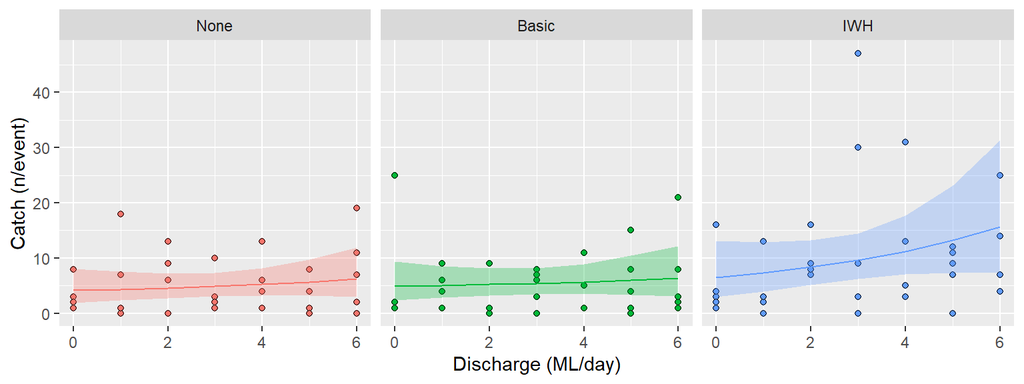

```r
  ds_mc$fit <- fitted(mod_mc, re_formula = NA)[,1]
  ds_mc$fit_lo <- fitted(mod_mc, re_formula = NA)[,3]
  ds_mc$fit_hi <- fitted(mod_mc, re_formula = NA)[,4]
  ggplot(ds_mc, aes(year, col=works, fill=works) ) +
    geom_point( aes( y=catch), pch=21,  col='black' ) +
    geom_line( aes(y=fit) ) +
    geom_ribbon( aes(ymin=fit_lo, ymax=fit_hi), alpha=0.3, col=NA ) +
      labs( x='Discharge (ML/day)', y='Catch (n/event)') +
      facet_wrap(~works, nrow=1) + theme(legend.position = 'none')
```

# Group Exercises

*(Assuming we have enough time…)*

Like yesterday, get in small groups and attempt one of the following small analysis tasks. Today’s tasks will use the same examples from above.

1. Using the skink dataset, re-run the model as using the Binomial distribution. This will involve the following task:
- grouping the data into temperature bins (and getting the number of successes per bin)
- using brm( success|trials(n) ~ …, data=data, family=binomial ) model formulation
- check the diagnostics
- plotting out the fitted model
2. For the Murray cod model, re-run the model using a Poisson distribution. Check the diagnostics to see issues that emerge.
3. For the Murray cod model, re-run the model summing all catch to each year for each works treatment. Compare the estimates from this model to the lecture’s one.